# Drillhole Tracking in R

Shane Lee

27/08/2023

## Drillhole Deviation Calculation QRG

#### 1000 - 1300 seconds run time

- Required in M:/Geology/leeshanea/R/csv/DDC:
  - *Projection survey.csv*
  - *Planned Survey.csv*
  - *Targets.csv*
- Outputs in M:/Geology/leeshanea/R/csv/exports/DDC:
  - *ProjectedvsPlanReport.pdf*
  - *DistanceReport.pdf*
  - *SectionViewReport.pdf*
  - *DistanceScatterPlot.png*

The old method was a three step process that required Leapfrog in the middle of the workflow to desurvey drillhole traces using its spherical arc approximation alogrithm. This new DDC script now condenses the three step process into one. Hence the user will only have to run the script with the formatted input files mentioned above.

**Get Rstudio:** If you do not have Rstudio installed on your device locally, the other option is to access Rstudio via Citrix.

[figure not shown]

Running Rstudio on your local device will naturally be faster and provide less complications due to the instability of the network and VPN at Oak Dam/Arcoona Station. To obtain Rstudio on your local device you may do so from the BHP service website https://bhp.service-now.com/sp. Type Rstudio in the search bar > Rstudio IDE, and request (It is free anyways!)

Once you have opened R locally or virtually, and the csvs are in its correct directory, you will need to open the script itself and run it. The location for this R script is here: [M:/Geology/leeshanea/R] as *DDC.R* To run the script click anywhere within the Source pane (default top left pane out of the 4 on your screen), Ctrl + A to select all, then Ctrl + Shift + S to run

### Understanding the results

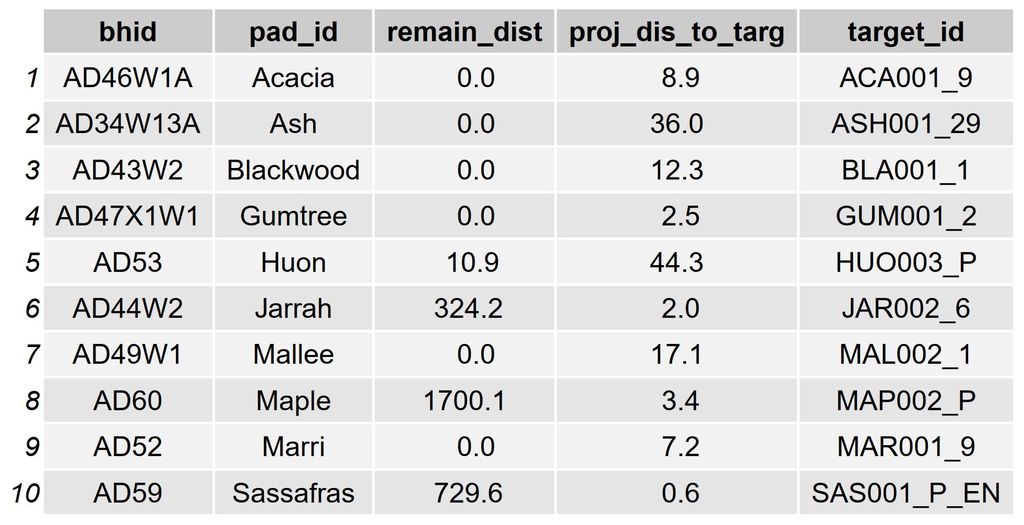

This table is the summary for each hole and their remaining distance to target. *remain_dist* shows how many meters left before the hole is about to intersect its target, hence if it is 0, it has passed its target and the column *proj_dis_to_targ* indicates the actual distance from the target. Otherwise it is the projected distance to target.

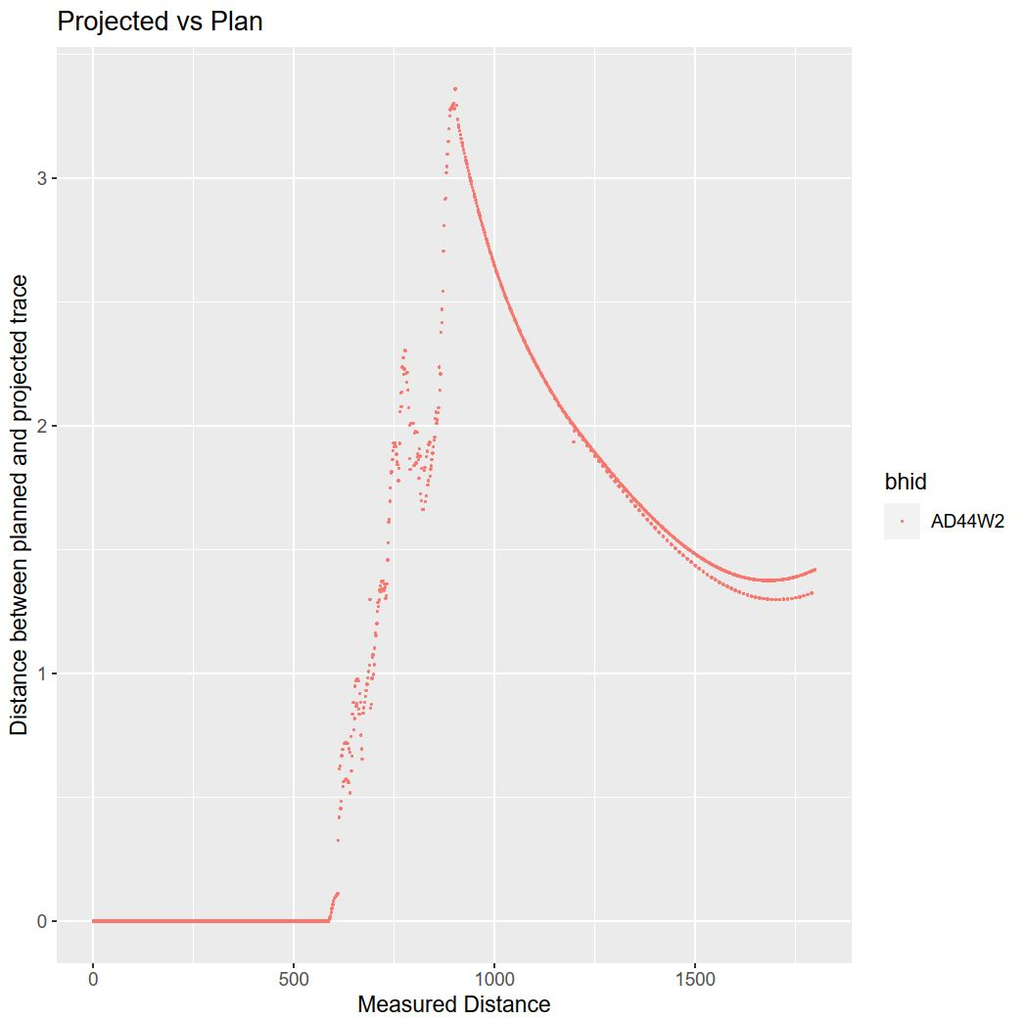

You may notice that the *ProjectedvsPlan* graphs plots weirdly at times. This artifact is only visual when the y-axis scale is small enough (0 - 5). This occurs due to the lack of alignment between the linear intperolations (lerp) of the projected data and the planned data. For example, if the lerped projected survey has points md = 444, 445 and 446, whilst the lerped planned survey only has 444 and 446, the distance between 444 and 446 points of both surveys could be etc. 0.1m, the point at 445 will be etc. 1m, hence a small spike in certain areas of the graph.

**Note:** If you do have Rstudio installed on your device, contact me (Shane Lee) and I can set up a batch file that runs the R script without requiring you to open Rstudio.

To create your own batch file, the code for running the R script via a batch file is shown below to copy. You will need to change the directories for the last four *xcopy* lines which are currently set to my personal folder on my drive *“C:Tracking”*. To create a batch file, open notepad, paste your edited code in, save as *DDC.bat* instead of the default *.txt*.

```
@echo off

:: Directory for environment variable to run Rscript
cd C:\Program Files\R\R-4.2.3\bin\

:: Run script via new directory
Rscript M:\Geology\leeshanea\R\DDC.R

@echo ------------------------
@echo ------------------------
@echo ------------------------

@echo Copying folders over.....

@echo off
xcopy "M:\Geology\leeshanea\R\csv\exports\DDC\DistanceReport.pdf" "C:\Users\leeshanea\Downloads\Drill Tracking" /s /y
xcopy "M:\Geology\leeshanea\R\csv\exports\DDC\ProjectedvsPlanReport.pdf" "C:\Users\leeshanea\Downloads\Drill Tracking" /s /y
xcopy "M:\Geology\leeshanea\R\csv\exports\DDC\SectionViewReport.pdf" "C:\Users\leeshanea\Downloads\Drill Tracking" /s /y
xcopy "M:\Geology\leeshanea\R\csv\exports\DDC\DistanceScatterPlot.png" "C:\Users\leeshanea\Downloads\Drill Tracking" /s /y

@echo off
echo PDFs imported from R folder leeshanea via Mdrive. Completed

@echo ------------------------

:: Completed emoji
type M:\Geology\leeshanea\R\Others\pipboy.txt

@echo ------------------------

pause
```

The old QRG has been archived to the bottom of the document.

Any questions do not hesitate to contact me. I appreciate any feedback and enjoy having a chat about this process

### Code (New)

```
#### Install and load packages ####
packages <- c("readxl","lubridate","tidyverse","ggplot2", "plotly", "tictoc", "knitr", "janitor", "gridExtra", "grid")
package.check <- lapply(
  packages,
  FUN = function(x) {
    if (!require(x, character.only = TRUE)) {
      install.packages(x, dependencies = TRUE)
      library(x, character.only = TRUE)
    }
  }
)

#### Clear environment & Timer ####
rm(list = ls()) ## Clear global environment
tic ()

#### Functions ####
# Radians to degree function
rad <- function(r){
  r * pi / 180
}
#### Source and wd (Import data - Acquire & Geo input csvs) ####
# Pull survey and collar data from M drive
setwd ("M:/Final/ACQUIRE/Exports/LFM")
OKD_surv <- read.csv("OAKDAM_MGA94-53_sur.csv")
OKD_col <- read.csv("OAKDAM_MGA94-53_col.csv")

# Change directory to read inputs
setwd ("M:/Geology/leeshanea/R/csv/DDC")
# Geo input csvs
Pjt_surv <- read.csv("Projection survey.csv")
plan_csv <- read.csv("Planned Survey.csv")
targ_csv <- read.csv("Targets.csv") # Change to all targets that team uses for LF?

# Initialize and clean dataframes
OKD_surv <- clean_names(OKD_surv)
OKD_col <- clean_names(OKD_col)
Pjt_surv <- clean_names(Pjt_surv)
plan_csv <- clean_names(plan_csv)
colnames(plan_csv)[1] <- "bhid"
```

[output cut: 478 more lines]

```
plot <- distance_report %>%
  ggplot(aes(x = append_date, y = proj_dis_to_targ, color = rig_id, group = rig_id)) +
  geom_point(size = 2, shape = 15) +
  geom_path() +
  xlab("Date") +
  ylab("Distance from planned target") +
  theme_classic() +
  geom_ribbon(data = NULL, aes(ymin = 0, ymax = 20), fill = "green", alpha = 0.01, color = NA) + # Color NA remove border
  geom_ribbon(data = NULL, aes(ymin = 20, ymax = 100), fill = "red", alpha = 0.01, color = NA) +
  coord_cartesian(ylim = c(0,50)) # Change axis without removing coordinates unlike ylim

setwd ("M:/Geology/leeshanea/R/csv/exports/DDC") # Change wd to export
ggsave(file = "DistanceScatterPlot.png", height = 3, width =7, dpi = 320) # Save plot
toc()
print("All done!, Thank you!")
```

## Drillhole Deviation Calculation QRG Pt.1 (Old method)

#### 20 - 30 seconds run time

###### TLDR

- Required in M:/Geology/leeshanea/R/csv folder:
  - *Projection survey.csv*
  - *Planned Survey.csv*
- Outputs in M:/Geology/leeshanea/R/csv/exports:
  - *Planned Collars.csv*
  - *SequencedCoordinates.csv*
  - *Projection collar.csv*
  - *Projection survey.csv*

This is 1 part of a 2 part process that is used to obtain the plots and deviation values from targets. This QRG will run you through the steps and required documents to run the scripts and the expected produced results. A troubleshoot section is attached at the end of the document.

If you do not have Rstudio installed on your device locally, the other option is to access Rstudio via Citrix. Running Rstudio on your local device will naturally be faster and provide less complications due to the instability of the network and VPN at Oak Dam/Arcoona Station. To obtain Rstudio on your local device you may do so from the BHP service website https://bhp.service-now.com/sp. Type Rstudio in the search bar > Rstudio IDE, and request (It is free anyways!)

[figure not shown]

The code chunk below shows the input data that will be used throughout the script, firstly it draws data from the collar and survey file updated daily within the M drive.

Other inputs that it requires from the user (Geos) are the *Projection Survey.csv* and the *Planned Survey.csv*. These csvs will need to be placed within the directory as listed below M:/Geology/leeshanea/R/csv. You may overwrite the csvs with the same name in that directory. Templates for how the content of the csv is formatted can be found a folder deeper within the Templates folder.

**Note:** Ensure that the BHID in the Planned survey matches to the BHID in the projection survey. This is mentioned specifically for redrills where AD47 may have been planned with that BHID, but is currently drilling as AD47X1. Hence the BHIDs in the planned survey must be of the **same format**.

**Note:** Contractor surveys are inconsistent with their formatting. Ensure that the data within the *Projection Survey.csv* has **-dip** and **Grid Azimuth**. The projection survey does not require you to knit your data with the live surveys. As it will be performed within the script itself

```r
#### Source and wd ####
## Pull survey and collar data from M drive
setwd ("M:/Final/ACQUIRE/Exports/LFM")

OKD_surv <- read.csv("OAKDAM_MGA94-53_sur.csv")
OKD_col <- read.csv("OAKDAM_MGA94-53_col.csv")

# Change directory to read inputs
setwd ("M:/Geology/leeshanea/R/csv")
```

```r
# To produce projection
Pjt_col <- OKD_col
Pjt_surv <- read.csv("Projection survey.csv")
```

```r
# For sequencing/LF Cartesian conversion
plan_csv <- read.csv("Planned Survey.csv")
```

Once you have opened R locally or virtually, and the csvs are in its correct directory, you will need to open the script itself and run it. The location for this R script is here: [M:/Geology/leeshanea/R] as *DrillholeDeviationCalculation1.R* To run the script click anywhere within the Source pane (default top left pane out of the 4 on your screen), Ctrl + A to select all, then Ctrl + Shift + S to run

The script should take on 20 - 25 seconds to run. It will then output the following csvs in their mentioned directories.

```r
#### File generation ####
# Write out csv - Sequence and planned collar
write.csv(seq_output, "M:/Geology/leeshanea/R/csv/exports/SequencedCoordinates.csv", row.names = FALSE)
write.csv(plan_col, "M:/Geology/leeshanea/R/csv/exports/Planned Collars.csv", row.names = FALSE)

#Write out csv - Projection survey and collar
write_csv(Pjt_col_final, "M:/Geology/leeshanea/R/csv/exports/Projection collar.csv", col_names = TRUE)
write_csv(Pjt_surv_final, "M:/Geology/leeshanea/R/csv/exports/Projection survey.csv", col_names = TRUE)
```

The projection collar and projection survey will now have the live surveys knitted within it. You may use this in your Leapfrog project to produce the traces of the projected holes for your daily tracking.

With those two csvs, you will also be provided the *Planned Collars.csv* and the *SequencedCoordinates.csv*. You are to use the input *Planned Surveys.csv*, in conjunction with these 4 output csvs within Leapfrog to desurvey them into coordinates, that will then be used for the next section.

Leapfrog uses spherical arc approximation by default in desurveying [(The dark art of drillhole desurveying)](https://www.seequent.com/the-dark-art-of-drillhole-desurveying/). The QRG to desurvey drillhole traces into Cartesian Coordinates can be found in sharepoint here Sharepoint - QRG De-surveying.docx

## Drillhole Deviation Calculation QRG Pt.2 (Old method)

#### 2800 - 3500 seconds run time

###### TLDR

- Required in M:/Geology/leeshanea/R/csv folder:
  - *Targets.csv*
  - *PlannedCoordinates.csv*
  - *ActualCoordinates.csv*
  - *SequencedCoordinates.csv*
- Outputs in M:/Geology/leeshanea/R/csv/exports:
  - *ProjectedvsPlanReport.pdf*
  - *DistanceReport.pdf*
  - *SectionViewReport.pdf*

As mentioned in the list above, there will be 4 required csvs from the user (Geos). *Targets.csv* will need to be generated by the user with the formatting shown in the M:/Geology/leeshanea/R/csv/Templates. The *PlannedCoordinates.csv* & *ActualCoordinates.csv* are to be generated from the de-surveying process within Leapfrog as mentioned at the end of the previous section. Similarly a copy of the *SequencedCoordinates.csv* is required, which is produced from Pt.1 with no modifications required.

**Note:** Similarly with formatting, ensure the BHID in *Targets.csv* matches to the currently drilling holes. Etc. Targeting AD44, and currently drilling as AD44X4 (4th redrill). Hence the BHID value in the csv should reflect that, as AD44X4. If there is a change in targets during mid-drilling process due to uncontrollable deviations, the XYZ coordinates must reflect that, otherwise calculations for distance to target will be based on old information. TargetID does not matter.

```r
#### Source and wd ####
## Pull survey and collar data from M drive
setwd ("M:/Final/ACQUIRE/Exports/LFM")

OKD_col <- read.csv("OAKDAM_MGA94-53_col.csv") # For section views

setwd ("M:/Geology/leeshanea/R/csv")
# setwd ("C:/Users/leeshanea/Downloads/Drill Tracking/Sample Data") # Change to M drive

csv_targets <- read.csv("Targets.csv")
plan_csv <- read.csv("PlannedCoordinates.csv")
act_csv <- read.csv("ActualCoordinates.csv")
depth_csv <- read.csv("Sequencedcoordinates.csv")
```

Once you have opened R locally or virtually, and the csvs are in its correct directory, you will need to open the script itself and run it. The location for this R script is here: [M:/Geology/leeshanea/R] as *DrillholeDeviationCalculation2.R* To run the script click anywhere within the Source pane (default top left pane out of the 4 on your screen), Ctrl + A to select all, then Ctrl + Shift + S to run

Your outputs will be a collection of graphs exported in a PDF format for you to snip and use in your reports. One of the PDFs is a distance report that shows the distance of the actual-projected trace from the target. The user (Geos) will have to look at the current drill depth of the hole to understand if the distance value is from the actual or the projected.

Below are examples of the graphs

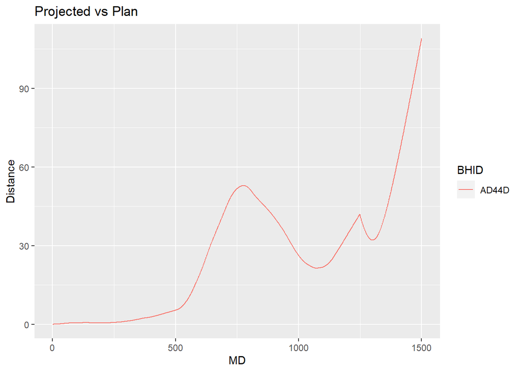

The graph plotted above shows the distance between the projected and the planned traces. The projected trace is a combination of live (actual) and projection. The live data supersedes the projection data, hence an understanding of where the hole is currently progressing in MD (Measured drilling meters) is crucial. Generic ideas can be made from trends where inflection points are attempts at re-correcting drilling/navi drilling and global minimas are attempts at closing in on the target

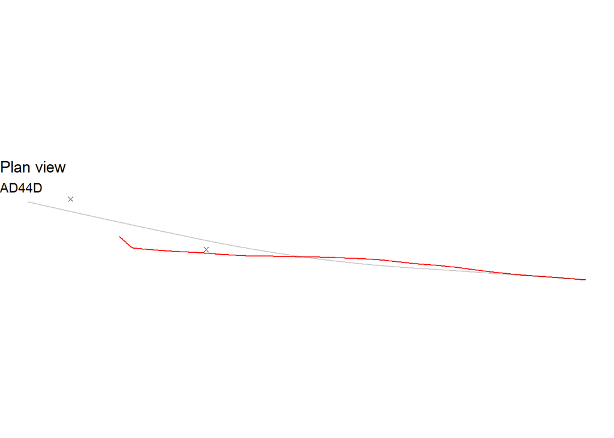

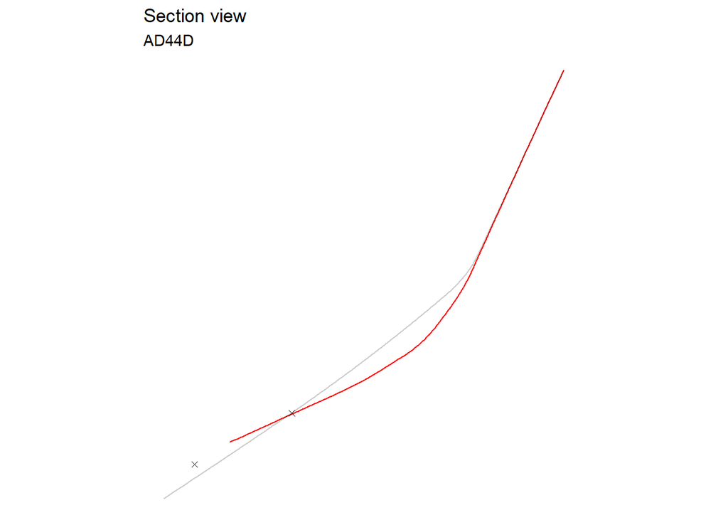

The graph plotted above shows the section views and planned views with a 1:1 scale on both axis, hence the plan view will be exaggerated based on the direction of drilling. Red is the live (actual) survey, whilst light grey is the planned.

| TargetID | MinimumDistance | BHID |
| --- | --- | --- |
| ACA001_P | 2.224846 | AD46C |
| ASH001_23 | 37.002672 | AD34W12A |
| ASH001_24 | 33.293468 | AD34W12A |
| BLA001_P_1W | 39.819809 | AD43A |
| GUM001_P | 76.538929 | AD47X1 |
| GUM001_P_1 | 65.963123 | AD47X1 |
| JAR002_P_1 | 67.490817 | AD44D |
| JAR002_P_2 | 49.541939 | AD44D |
| MAL002_P | 12.095010 | AD49 |
| MAP001_P | 10.256730 | AD45X1 |
| MAR001_7 | 23.824550 | AD40W4A |

The final PDF which consists of only a table is for the user (Geos) to identify how close we are to hitting our targets. The value of the distance to target is based on the projection trace (which consists of live/actual and projection surveys). Hence, if the daily report mentions the current hole is past target, the distance is “actual distance from target”. Otherwise it is “projected distance from target”

## Appendix

### FAQ (Old method)

1. I have populated the *Projection survey.csv* for the 1st part of the script but the output *Projection survey.csv* and *Projection collar.csv* does not show the holes I have populated in the input csv. Now when I upload my projections into Leapfrog it does not show up!
   - It is good practice to ensure the *Planned Survey.csv* has been populated correctly with the correct BHIDs. Another factor would be that the collar does not exist in the database yet (Collar not yet entered?), and that the LFM csvs in the M drive only updates daily mid-day (which is what this script references from).
2. I have ran the script (Ctrl + A -> Ctrl + Shift + S) but nothing is happening? How do I know that my Rstudio has not frozen up/failed/finished etc.
   - After running the script, the console (bottom left panel) will show lines of code being ran, hence you would see movement as it goes through each line. However, there are some lines that are more complex. When this happens, a small stop sign at the top right of the console panel will appear, which would allow the user to interrupt the process. These are signs that the script is running. There are also expected run times mentioned below the header of each section.
3. I have ran both scripts and the minimum distance output for one/some of the holes in the *DistanceReport.pdf* show *Inf* instead of expected values.
   - Data duplicates and format are the main culprits for this error. Ensure that the BHIDs are matched up correctly across all input csvs (sometimes there might be a space behind typed BHID etc. ~AD52 ~). Data duplicates such as duplicate surveys would prevent Leapfrog from de-surveying that respective hole’s trace, and hence would not be exported as a *Actual/PlannedCoordinates.csv* to be used in the 2nd script. These can be troubleshooted from Leapfrog itself to identify where the duplicate is, which can be fixed through Leapfrog itself (ignore row) or managed in the *Projection survey.csv* and *Planned survey.csv* (recommended method for handover to multiple users of the script).
4. The *SectionViewReport.pdf* has missing holes. However, they have been generated fine in the *ProjectedvsPlanReport.pdf* and *DistanceReport.pdf*
   - The plan and section graphs in the report are plotted based on the data generated from AcQuire (LFM). If the surveys from the contractors are still not uploaded into the database, or the core depth in AcQuire is = 0, nothing will be plotted. Take note if this has been rectified straight away in the database, the data will only be available mid-day as that is when the database dumps the csvs into the M drive daily.

### Data flowchart (Old method)

[figure not shown]

### Code (Old)

```
#### Install and load packages ####
packages <- c("readxl","lubridate","tidyverse","ggplot2", "plotly", "tictoc", "knitr")
package.check <- lapply(
  packages,
  FUN = function(x) {
    if (!require(x, character.only = TRUE)) {
      install.packages(x, dependencies = TRUE)
      library(x, character.only = TRUE)
    }
  }
)

#### Clear environment & Timer ####
rm(list = ls()) ## Clear global environment
tic ()

#### Source and wd ####
## Pull survey and collar data from M drive
setwd ("M:/Final/ACQUIRE/Exports/LFM")

OKD_surv <- read.csv("OAKDAM_MGA94-53_sur.csv")
OKD_col <- read.csv("OAKDAM_MGA94-53_col.csv")

# Change directory to read inputs
setwd ("M:/Geology/leeshanea/R/csv/DDC")

# To produce projection
Pjt_col <- OKD_col
Pjt_surv <- read.csv("Projection survey.csv")
colnames(Pjt_surv)[1] = "BHID" #Format col name

# For sequencing/LF Cartesian conversion
plan_csv <- read.csv("Planned Survey.csv")

#### Produce Projection ####
## Filter
# Obtain latest MD from OKD_surv
Pjt_merge_depth <- OKD_surv %>%
  arrange(desc(DEPTH)) %>%
  distinct(BHID, .keep_all = TRUE) %>%
```

[output cut: 83 more lines]

```
plan_col$EOH <- plan_col_EOH

#### File generation ####
# Write out csv - Sequence and planned collar
write.csv(seq_output, "M:/Geology/leeshanea/R/csv/exports/DDC/SequencedCoordinates.csv", row.names = FALSE)
write.csv(seq_output, "M:/Geology/leeshanea/R/csv/DDC/SequencedCoordinates.csv", row.names = FALSE)
write.csv(plan_col, "M:/Geology/leeshanea/R/csv/exports/DDC/Planned Collars.csv", row.names = FALSE)

#Write out csv - Projection survey and collar
write_csv(Pjt_col_final, "M:/Geology/leeshanea/R/csv/exports/DDC/Projection collar.csv", col_names = TRUE)
write_csv(Pjt_surv_final, "M:/Geology/leeshanea/R/csv/exports/DDC/Projection survey.csv", col_names = TRUE)

# Print comment
toc()
noquote("csvs generated")
```

```
#### Install and load packages ####
packages <- c("readxl","lubridate","tidyverse","ggplot2", "plotly", "tictoc", "knitr", "gridExtra")
package.check <- lapply(
  packages,
  FUN = function(x) {
    if (!require(x, character.only = TRUE)) {
      install.packages(x, dependencies = TRUE)
      library(x, character.only = TRUE)
    }
  }
)

#### Clear environment & Timer ####
rm(list = ls()) ## Clear global environment
tic ()

#### Source and wd ####
## Pull survey and collar data from M drive
setwd ("M:/Final/ACQUIRE/Exports/LFM")

OKD_col <- read.csv("OAKDAM_MGA94-53_col.csv") # For section views

setwd ("M:/Geology/leeshanea/R/csv/DDC")
# setwd ("C:/Users/leeshanea/Downloads/Drill Tracking/Sample Data") # Change to M drive

csv_targets <- read.csv("Targets.csv")
plan_csv <- read.csv("PlannedCoordinates.csv")
act_csv <- read.csv("ActualCoordinates.csv")
depth_csv <- read.csv("Sequencedcoordinates.csv") %>%
  select(BHID, From)

# Format names
colnames(plan_csv)[4] <- "BHID"
colnames(act_csv)[4] <- "BHID"
colnames(csv_targets)[5] <- "BHID"

#### Subset for plan_csv, add depth column for coordinates ####
# Create MD for each hole ID. Subsetting using dplyr filter and select.
fil1 <- plan_csv %>% # Create list of hole ids to subset
  distinct(BHID)
```

[output cut: 243 more lines]

```
  Section_view <- fil2 %>%
    ggplot() +
    geom_path(data = fil2, aes(Actual_X, Actual_Z), colour = "Red", alpha = 1) +
    geom_path(data = fil3, aes(Planned_X, Planned_Z), colour = "Black", alpha = 0.2) +
    geom_point(data = fil4, aes(x, z), shape = 4) +
    labs(title = "Section view", subtitle = nam, x = "Easting", y = "RL") +
    coord_equal() +
    theme_void()

  print(Plan_view)
  print(Section_view)
}
dev.off()

toc()
```